# Lab4

## MA Model

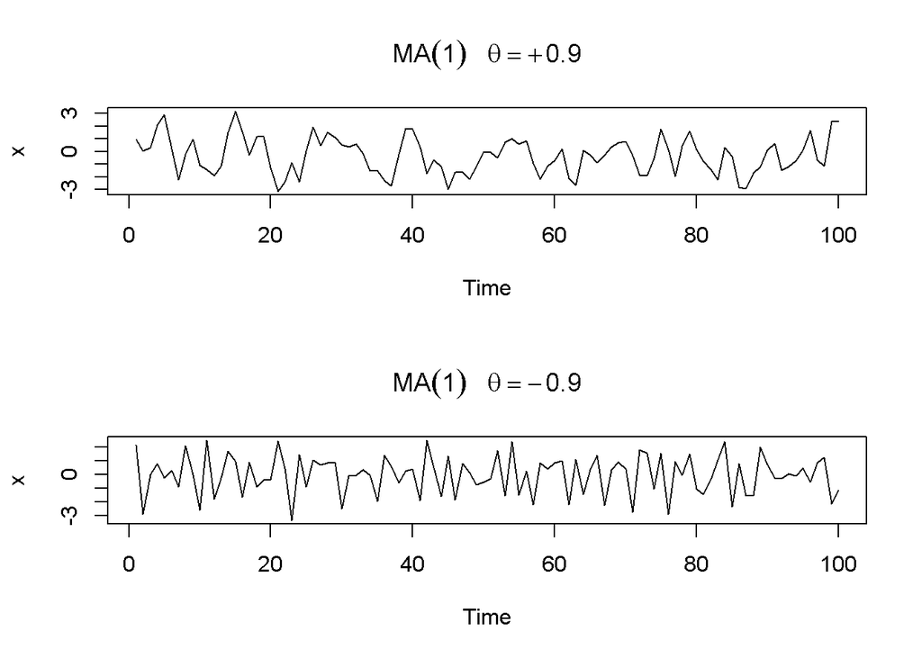

```r
par(mfrow = c(2,1))
plot(arima.sim(list(order=c(0,0,1), ma=.9), n=100), ylab="x",
     main=(expression(MA(1)~~~theta==+.9)))
plot(arima.sim(list(order=c(0,0,1), ma=-.9), n=100), ylab="x",
        main=(expression(MA(1)~~~theta==-.9)))
```

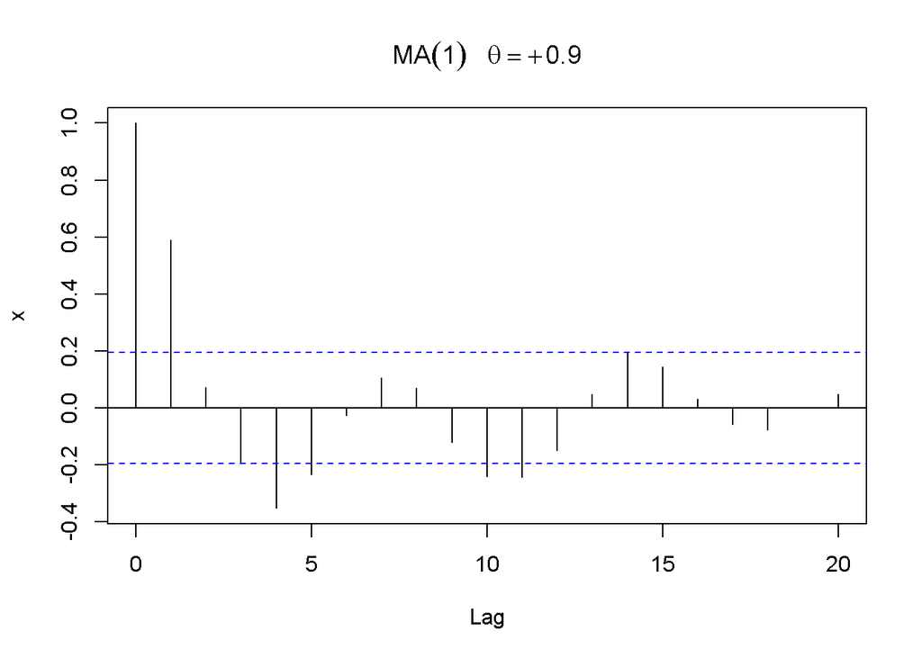

```r
acf(arima.sim(list(order=c(0,0,1), ma=.9), n=100), ylab="x",
     main=(expression(MA(1)~~~theta==+.9)))
```

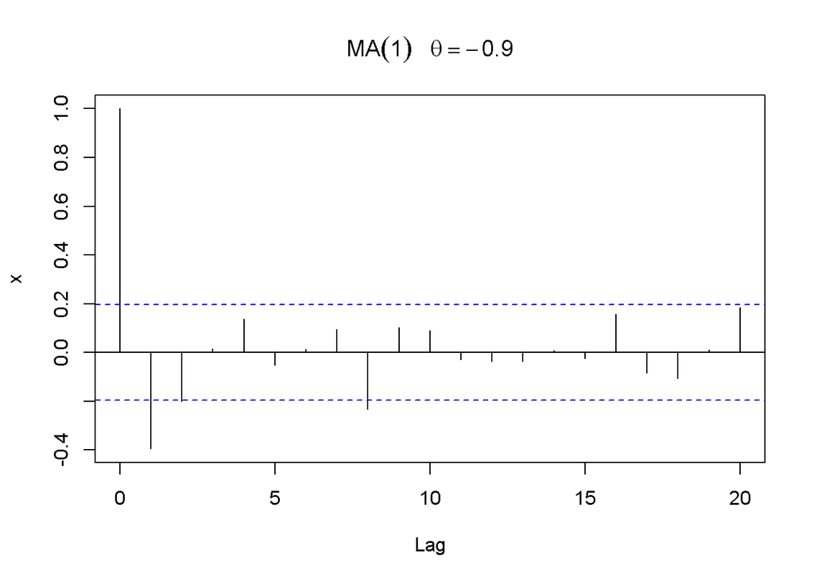

```r
acf(arima.sim(list(order=c(0,0,1), ma=-.9), n=100), ylab="x",
     main=(expression(MA(1)~~~theta==-.9)))
```

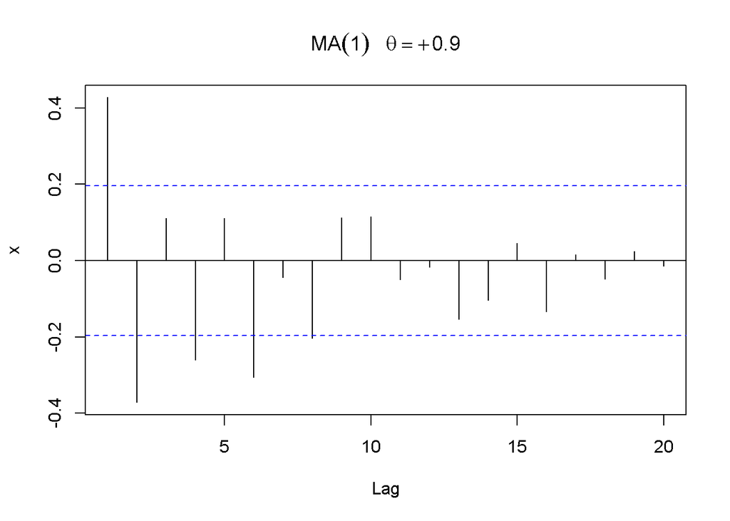

```r
pacf(arima.sim(list(order=c(0,0,1), ma=.9), n=100), ylab="x",
    main=(expression(MA(1)~~~theta==+.9)))
```

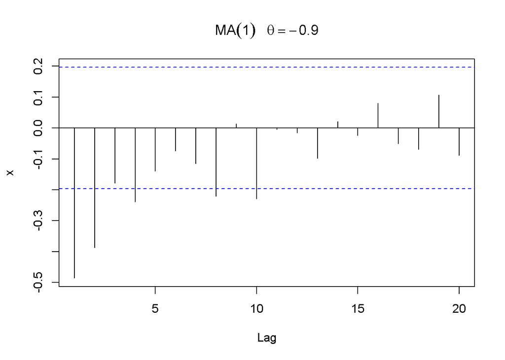

```r
pacf(arima.sim(list(order=c(0,0,1), ma=-.9), n=100), ylab="x",
    main=(expression(MA(1)~~~theta==-.9)))
```

```r
set.seed(151)
xt=arima.sim(list(order=c(0,0,1), ma=.9),n=1000)
auto.arima(xt)
```

```
## Series: xt
## ARIMA(0,0,1) with zero mean
##
## Coefficients:
##          ma1
##       0.9099
## s.e.  0.0123
##
## sigma^2 = 0.976:  log likelihood = -1407.16
## AIC=2818.32   AICc=2818.33   BIC=2828.13
```

## Moving Average Smoothing

(Centered Moving Average) We might replace the white noise series $w_t$ by a moving average that smooths the series. For example, consider replacing the white noise mentioned above, $w_t$ by an average of its current value and its immediate neighbors in the past and future. That is, let

$v_t= \frac{1}{3}(w_{t-1} + w_t + w_{t+1} )$

A linear combination of values in a time series such as in above formula, is referred to, generically, as a filtered series; hence the command filter has been used.

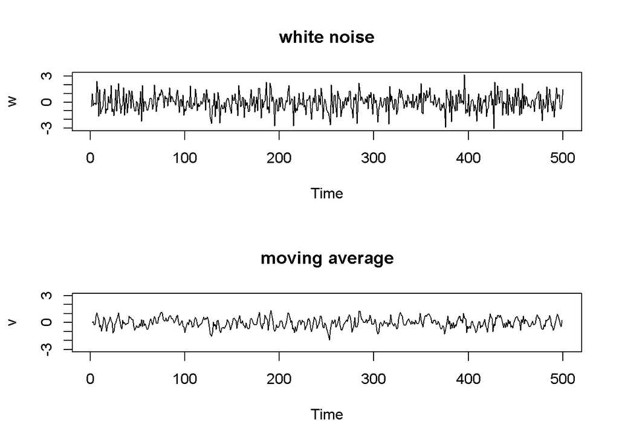

```r
w = rnorm(500,0,1) # 500 N(0,1) variates
v = filter(w, sides=2, filter=rep(1/3,3)) # moving average
par(mfrow=c(2,1))
plot.ts(w, main="white noise")
plot.ts(v, ylim=c(-3,3), main="moving average")
```

Inspecting the series shows a smoother version of the first series, reflecting the fact that the slower oscillations are more apparent and some of the faster oscillations are taken out.

### Example: Residential electricity sales (excluding hot water) for South Australia: 1989–2008.

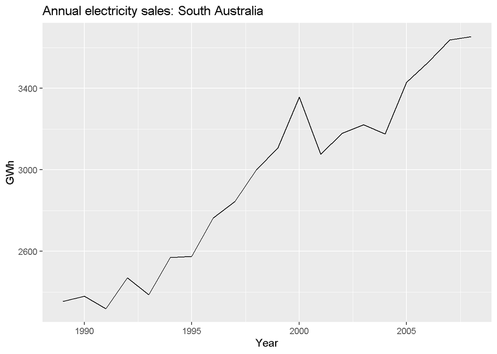

```r
autoplot(elecsales) + xlab("Year") + ylab("GWh") +
  ggtitle("Annual electricity sales: South Australia")
```

```r
ma(elecsales, 5) #calculate 5-MA
```

```
## Time Series:
## Start = 1989
## End = 2008
## Frequency = 1
##  [1]       NA       NA 2381.530 2424.556 2463.758 2552.598 2627.700 2750.622
##  [9] 2858.348 3014.704 3077.300 3144.520 3188.700 3202.320 3216.940 3307.296
## [17] 3398.754 3485.434       NA       NA
```

5-MA

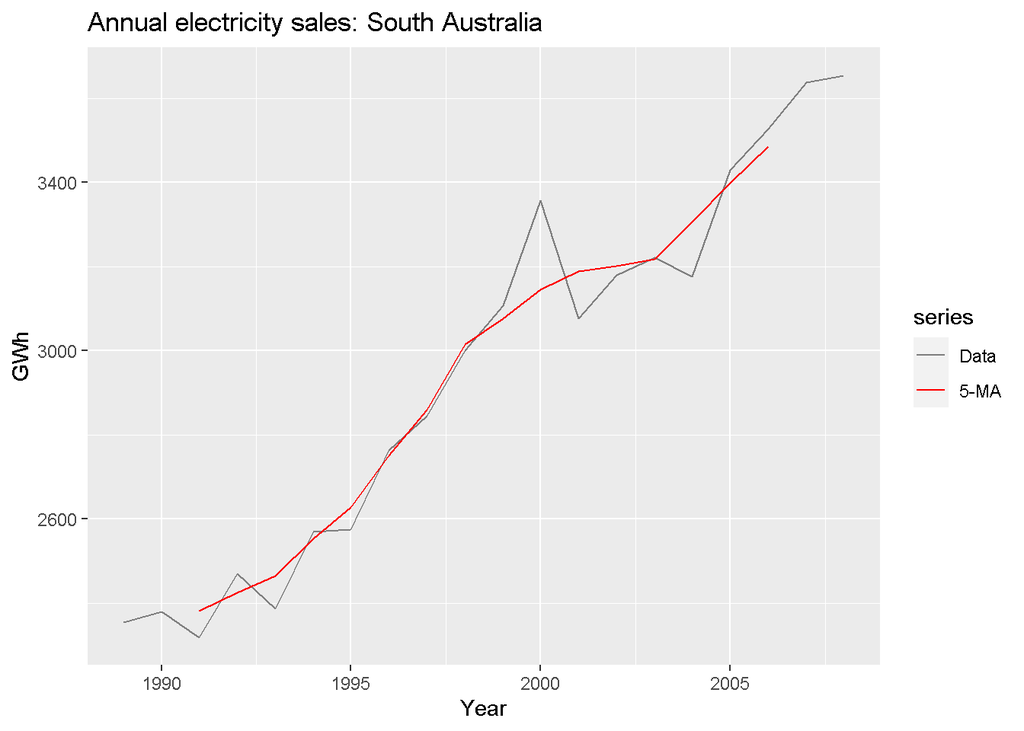

```r
autoplot(elecsales, series="Data") +
  autolayer(ma(elecsales,5), series="5-MA") +
  xlab("Year") + ylab("GWh") +
  ggtitle("Annual electricity sales: South Australia") +
  scale_colour_manual(values=c("Data"="grey50","5-MA"="red"),
                      breaks=c("Data","5-MA"))
```

Notice that the trend-cycle (in red) is smoother than the original data and captures the main movement of the time series without all of the minor fluctuations. The order of the moving average determines the smoothness of the trend-cycle estimate. In general, a larger order means a smoother curve.

The effect of changing the order of the moving average for the residential electricity sales data.

```r
library(gridExtra)
```

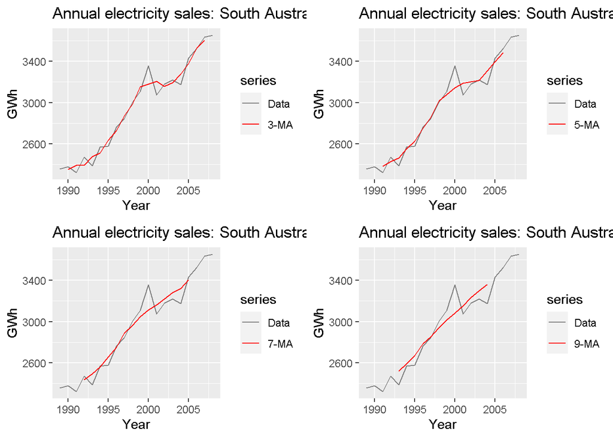

```r
ma3 <- autoplot(elecsales, series="Data") +
  autolayer(ma(elecsales,3), series="3-MA") +
  xlab("Year") + ylab("GWh") +
  ggtitle("Annual electricity sales: South Australia") +
  scale_colour_manual(values=c("Data"="grey50","3-MA"="red"),
                      breaks=c("Data","3-MA"))

ma5 <- autoplot(elecsales, series="Data") +
  autolayer(ma(elecsales,5), series="5-MA") +
  xlab("Year") + ylab("GWh") +
  ggtitle("Annual electricity sales: South Australia") +
  scale_colour_manual(values=c("Data"="grey50","5-MA"="red"),
                      breaks=c("Data","5-MA"))


ma7 <- autoplot(elecsales, series="Data") +
  autolayer(ma(elecsales,7), series="7-MA") +
  xlab("Year") + ylab("GWh") +
  ggtitle("Annual electricity sales: South Australia") +
  scale_colour_manual(values=c("Data"="grey50","7-MA"="red"),
                      breaks=c("Data","7-MA"))

ma9 <- autoplot(elecsales, series="Data") +
  autolayer(ma(elecsales,9), series="9-MA") +
  xlab("Year") + ylab("GWh") +
  ggtitle("Annual electricity sales: South Australia") +
  scale_colour_manual(values=c("Data"="grey50","9-MA"="red"),
                      breaks=c("Data","9-MA"))

grid.arrange(ma3, ma5,ma7,ma9, nrow = 2, ncol=2)
```

Simple moving averages such as these are usually of an odd order (e.g., 3, 5, 7, etc.). This is so they are symmetric: in a moving average of order m=2k+1, the middle observation, and k observations on either side, are averaged. But if m was even, it would no longer be symmetric.

## Moving averages of moving averages (even-order moving window)

It is possible to apply a moving average to a moving average. One reason for doing this is to make an even-order moving average symmetric.

```r
beer2 <- window(ausbeer,start=1992)
ma4 <- ma(beer2, order=4, centre=FALSE)
ma2x4 <- ma(beer2, order=4, centre=TRUE)
MA=data.frame()
```

### Example: Electrical equipment manufacturing

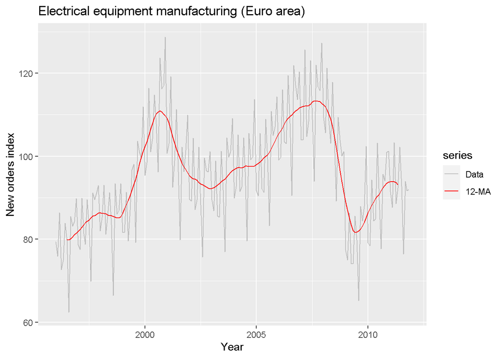

```r
autoplot(elecequip, series="Data") +
  autolayer(ma(elecequip, 12, centre=TRUE), series="12-MA") +
  xlab("Year") + ylab("New orders index") +
  ggtitle("Electrical equipment manufacturing (Euro area)") +
  scale_colour_manual(values=c("Data"="grey","12-MA"="red"),
                      breaks=c("Data","12-MA"))
```

A 2x12-MA applied to the electrical equipment orders index.

Notice that the smooth line shows no seasonality; Any other choice for the order of the moving average (except for 24, 36, etc.) would have resulted in a smooth line that showed some seasonal fluctuations.